# Description

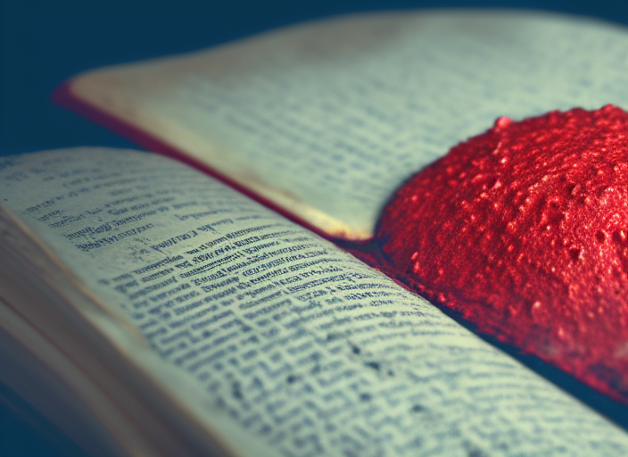

The coronavirus took the entire world by surprise, changing everyone's daily routine. City dwellers no longer spent their free time outside, going to cafes and malls; more people were home, reading books. That attracted the attention of startups that rushed to develop new apps for book lovers.

I've been given a database of one of the services competing in this market. It contains data on books, publishers, authors, and customer ratings and reviews of books. This information will be used to generate a value proposition for a new product.

**Description of the data :**

**books:**

Contains data on books:

`book_id`

`author_id`

`title`

`num_pages` — number of pages

`publication_date`

`publisher_id`

**authors:**

Contains data on authors:

`author_id`

`author`

**publishers:**

Contains data on publishers:

`publisher_id`

`publisher`

**ratings:**

Contains data on user ratings:

`rating_id`

`book_id`

`username` — the name of the user who rated the book

`rating`

**reviews:**

Contains data on customer reviews:

`review_id`

`book_id`

`username` — the name of the user who reviewed the book

`text` — the text of the review

## The goal of the study

Generate information for making a value proposition for a new product.

## Access to the data base

```python
#import libraries

import pandas as pd
from sqlalchemy import create_engine
```

```python
#Creating a database connection

db_config = {'user': 'praktikum_student',         # user name
             'pwd': 'Sdf4$2;d-d30pp', # password
             'host': 'rc1b-wcoijxj3yxfsf3fs.mdb.yandexcloud.net',
             'port': 6432,              # connection port
             'db': 'data-analyst-final-project-db'}          # the name of the data base

connection_string = 'postgresql://{}:{}@{}:{}/{}'.format(db_config['user'],
                                                                     db_config['pwd'],
                                                                       db_config['host'],
                                                                       db_config['port'],
                                                                       db_config['db'])

engine = create_engine(connection_string, connect_args={'sslmode':'require'})


# The connection is stored in the engine variable.
#    run a SQL query using pandas
#    pd.io.sql.read_sql(query, con = engine)
```

## Tables

check and study Tables, print first few rows from each table

```python
# set a query object, returns the query givin in SQL
def query(sql):
    return pd.io.sql.read_sql(sql, con = engine)
```

```python
# check total rows in books dataset - our main dataset
query(''' SELECT count(*) as total FROM books  ''')
```

|  | total |
| --- | --- |
| 0 | 1000 |

**books**

```python
books = ''' SELECT * FROM books LIMIT 5 '''
query(books)
```

|  | book_id | author_id | title | num_pages | publication_date | publisher_id |
| --- | --- | --- | --- | --- | --- | --- |
| 0 | 1 | 546 | 'Salem's Lot | 594 | 2005-11-01 | 93 |
| 1 | 2 | 465 | 1 000 Places to See Before You Die | 992 | 2003-05-22 | 336 |
| 2 | 3 | 407 | 13 Little Blue Envelopes (Little Blue Envelope... | 322 | 2010-12-21 | 135 |
| 3 | 4 | 82 | 1491: New Revelations of the Americas Before C... | 541 | 2006-10-10 | 309 |
| 4 | 5 | 125 | 1776 | 386 | 2006-07-04 | 268 |

**authors**

```python
authors = ''' SELECT * FROM authors LIMIT 5 '''
query(authors)
```

|  | author_id | author |
| --- | --- | --- |
| 0 | 1 | A.S. Byatt |
| 1 | 2 | Aesop/Laura Harris/Laura Gibbs |
| 2 | 3 | Agatha Christie |
| 3 | 4 | Alan Brennert |
| 4 | 5 | Alan Moore/David Lloyd |

```python
authors = ''' SELECT * FROM authors LIMIT 5 '''
query(authors)
```

|  | author_id | author |
| --- | --- | --- |
| 0 | 1 | A.S. Byatt |
| 1 | 2 | Aesop/Laura Harris/Laura Gibbs |
| 2 | 3 | Agatha Christie |
| 3 | 4 | Alan Brennert |
| 4 | 5 | Alan Moore/David Lloyd |

**ratings**

```python
ratings = ''' SELECT * FROM ratings LIMIT 5 '''
query(ratings)
```

|  | rating_id | book_id | username | rating |
| --- | --- | --- | --- | --- |
| 0 | 1 | 1 | ryanfranco | 4 |
| 1 | 2 | 1 | grantpatricia | 2 |
| 2 | 3 | 1 | brandtandrea | 5 |
| 3 | 4 | 2 | lorichen | 3 |
| 4 | 5 | 2 | mariokeller | 2 |

**publishers**

```python
publishers = ''' SELECT * FROM publishers LIMIT 5 '''
query(publishers)
```

|  | publisher_id | publisher |
| --- | --- | --- |
| 0 | 1 | Ace |
| 1 | 2 | Ace Book |
| 2 | 3 | Ace Books |
| 3 | 4 | Ace Hardcover |
| 4 | 5 | Addison Wesley Publishing Company |

**reviews**

```python
reviews = ''' SELECT * FROM reviews LIMIT 5 '''
query(reviews)
```

|  | review_id | book_id | username | text |
| --- | --- | --- | --- | --- |
| 0 | 1 | 1 | brandtandrea | Mention society tell send professor analysis. ... |
| 1 | 2 | 1 | ryanfranco | Foot glass pretty audience hit themselves. Amo... |
| 2 | 3 | 2 | lorichen | Listen treat keep worry. Miss husband tax but ... |
| 3 | 4 | 3 | johnsonamanda | Finally month interesting blue could nature cu... |
| 4 | 5 | 3 | scotttamara | Nation purpose heavy give wait song will. List... |

# Query Points

points that I belive will help the Startup in getting valuebale Insights

- the number of books released after January 1, 2000.
- the number of user reviews and the average rating for each book.
- the publisher that has released the greatest number of books with more than 50 pages (this will help excluding brochures and similar publications from the analysis).
- the author with the highest average book rating (books with at least 50 ratings).
- the average number of text reviews among users who rated more than 50 books.

## the number of books released after January 1, 2000

```python
books_total =  ''' SELECT COUNT(book_id) FROM books AS books_number
                 WHERE publication_date > '2000-01-01' '''
query(books_total)
```

|  | count |
| --- | --- |
| 0 | 819 |

## the number of user reviews and the average rating for each book

```python
avg_rating = ''' SELECT b.title, COUNT( review_id) as review_count, AVG(rating) as avg_rating
                FROM books b
                INNER JOIN ratings ON ratings.book_id = b.book_id
                INNER JOIN reviews ON reviews.book_id = ratings.book_id
                GROUP BY title
                ORDER BY review_count DESC,avg_rating ASC  '''
query(avg_rating)
```

|  | title | review_count | avg_rating |
| --- | --- | --- | --- |
| 0 | Twilight (Twilight #1) | 1120 | 3.662500 |
| 1 | The Hobbit or There and Back Again | 528 | 4.125000 |
| 2 | The Catcher in the Rye | 516 | 3.825581 |
| 3 | Harry Potter and the Prisoner of Azkaban (Harr... | 492 | 4.414634 |
| 4 | Harry Potter and the Chamber of Secrets (Harry... | 480 | 4.287500 |
| ... | ... | ... | ... |
| 988 | The Philosophy of Andy Warhol (From A to B and... | 2 | 4.500000 |
| 989 | Creepshow | 2 | 4.500000 |
| 990 | Stone of Farewell (Memory Sorrow and Thorn #2) | 2 | 5.000000 |
| 991 | How to Be a Domestic Goddess: Baking and the A... | 2 | 5.000000 |
| 992 | The Adventures of Tom Sawyer and Adventures of... | 2 | 5.000000 |

993 rows × 3 columns

## the publisher that has released the greatest number of books with more than 50 pages

```python
publisher_50 = '''SELECT p.publisher, COUNT(b.book_id) as books_count
                  FROM books AS b
                  INNER JOIN publishers AS p
                  ON b.publisher_id = p.publisher_id and num_pages > 50
                  GROUP BY publisher
                  ORDER BY books_count DESC
                  LIMIT 1 '''
query(publisher_50)
```

|  | publisher | books_count |
| --- | --- | --- |
| 0 | Penguin Books | 42 |

## the author with the highest average book rating (books with at least 50 ratings)

```python
author_50 = ''' SELECT a.author, b.title, AVG (r.rating) avg_rating, COUNT(r.rating_id) AS rating_count
                FROM books AS b
                INNER JOIN authors AS a
                ON a.author_id = b.author_id
                INNER JOIN ratings AS r
                ON r.book_id = b.book_id
                GROUP BY author, title
                HAVING  COUNT(r.rating_id) > 50
                ORDER BY avg_rating DESC
                limit 1'''
query(author_50)
```

|  | author | title | avg_rating | rating_count |
| --- | --- | --- | --- | --- |
| 0 | J.K. Rowling/Mary GrandPré | Harry Potter and the Prisoner of Azkaban (Harr... | 4.414634 | 82 |

## the average number of text reviews among users who rated more than 50 books

```python
text_50 = ''' SELECT COUNT(text)/COUNT(DISTINCT username) AS text_review_avg
              FROM reviews
              WHERE username IN (
              SELECT username
              FROM ratings
              GROUP BY username
              HAVING COUNT(*) > 50)'''
query(text_50)
```

|  | text_review_avg |
| --- | --- |
| 0 | 24 |

## Conclusion

It seems that most books are released after the year 2000, thou most books have pretty high average ratings with 3+ we need to consider the review count alongside average rating to have a decent minimum starting point to be in the suggested books.

As we mentioned before, we want books with over 50 pages so it won't include brochures or similarly short publications. The Publisher “Penguin Books” excel in this “Real book” category, highly advised to include them.

All in all, we have a pretty decent starting point for our Product.

[figure not shown]

(*another AI Created Image, Fantasy Stories are ageles*)